# Soc-Xsit Plots

Kyle MacDonald

This script creates the plots for the paper: “Social cues modulate the representations underlying cross-situational learning”

Read in data from all 4 Experiments:

- Experiment 1: Large scale experiment manipulating attention and memory demands
- Experiment 2: Replication of Experiment 1 with more ecologically valid stimulus set
- Experiment 3: Parametric manipulation of cue reliablity
- Experiment 4: Fixed inspection time for each exposure trial: two lengths – short (6 sec) vs. long (9 sec)

## Experiment 1

### Inspection time on exposure trials and Accuracy at test

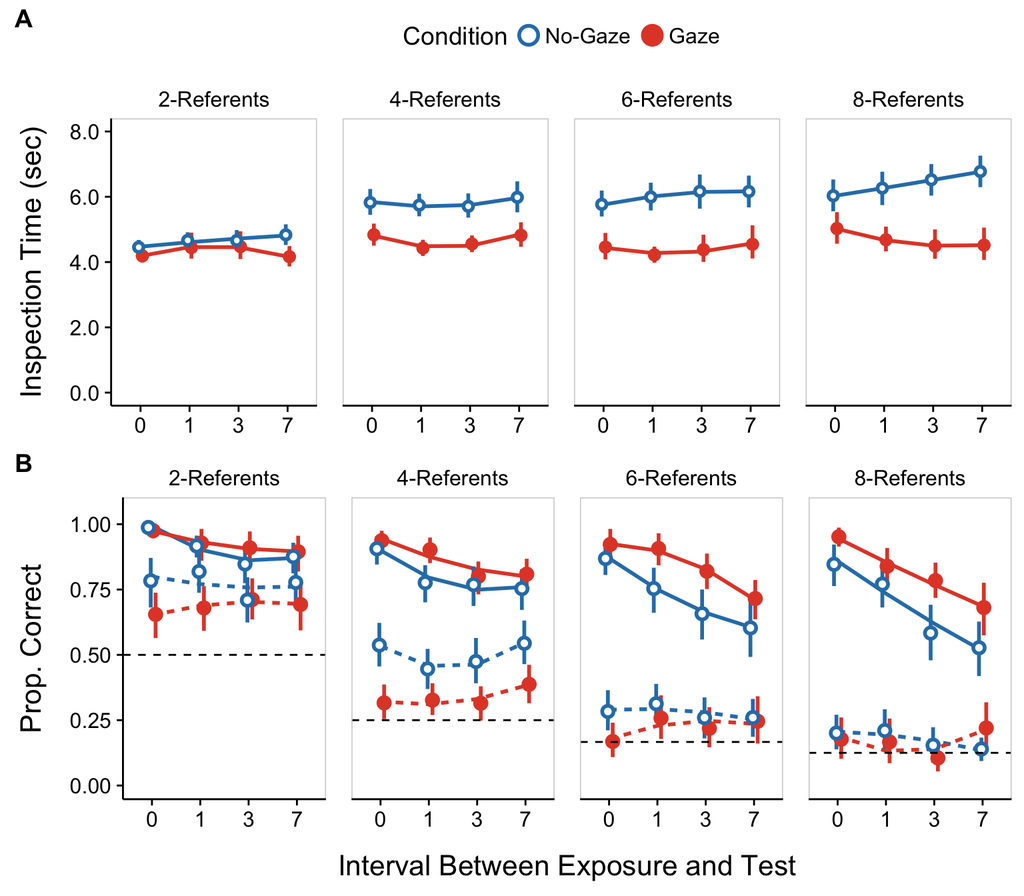

## Experiment 2

Tested a subset of the referent/interval conditions: 4-referent and 0-/3-interval in order to replicate findings from Experiment 1 with a more ecologically valid social cue.

### Inspection time on exposure trials and accuracy at test

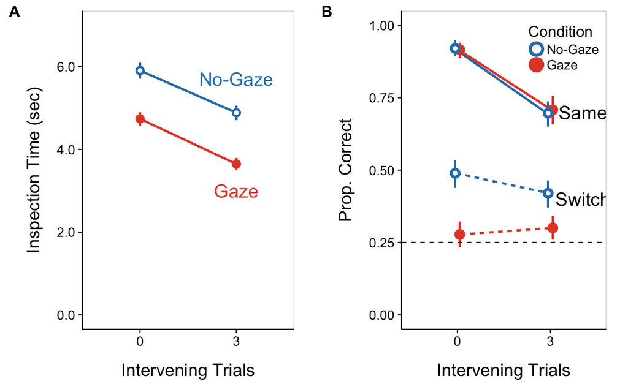

## Experiment 3

Manipulated cue reliablity with 5 levels of reliability – 0%, 25%, 50%, 75%, and 100% – to test if learners would show graded changes in amount of information stored during learning.

### Performance at test as a function of reliability condition

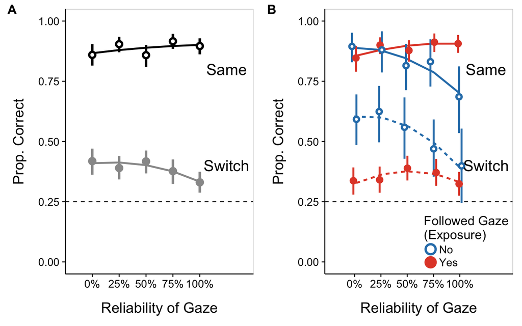

### Performance at test as a function of gaze use and subjective reliability

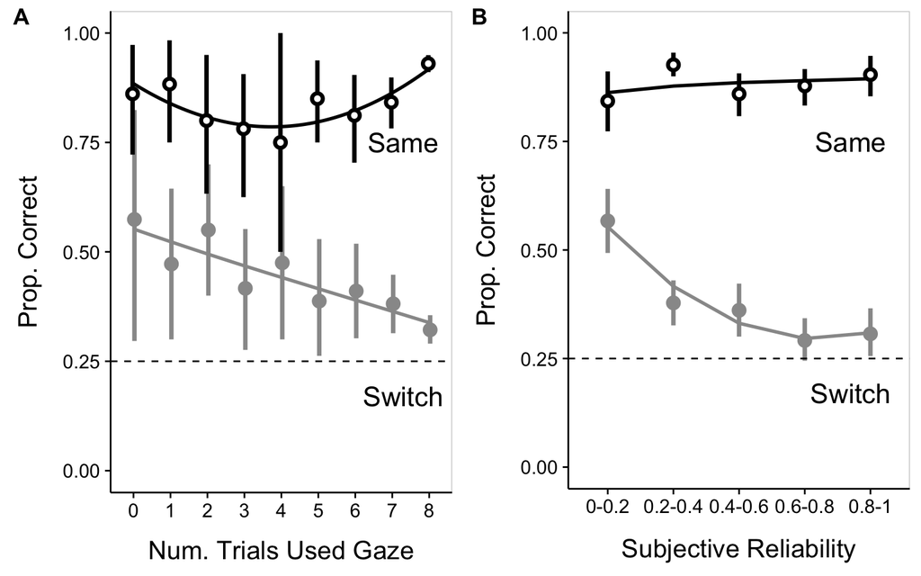

## Experiment 4

Fixed inspection time for exposure trials in the gaze and no-gaze conditions: two lengths – short (6 sec) vs. long (9 sec). Tested for an effect of gaze over and above reduced inspection time.

### Performance at test as a function of interval and gaze condition

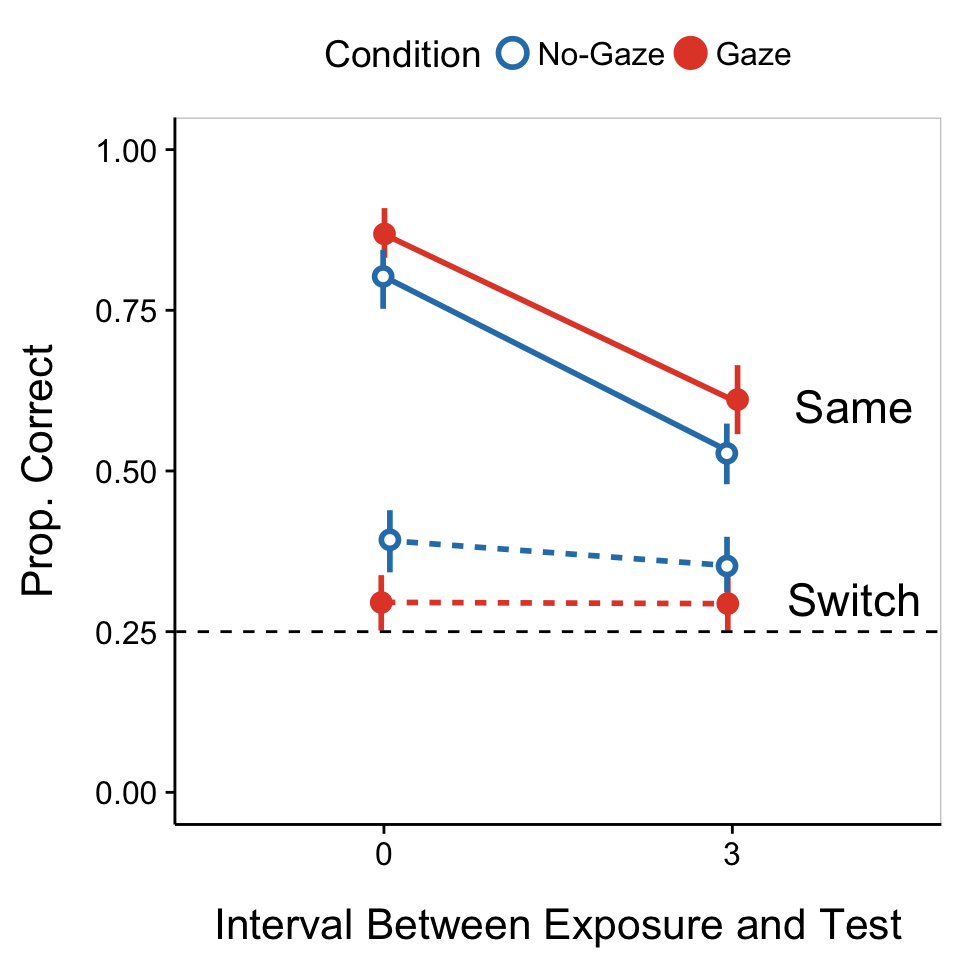